# Visualization

Anatoliy Sozontov

2023-11-06

```r
raw_data <- read_csv("insurance_cost.csv")
```

### Гистограммы для нумерик перемменных

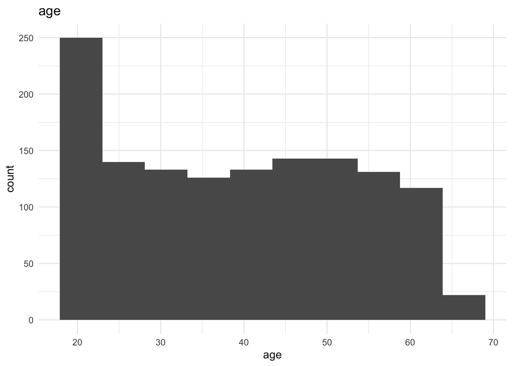

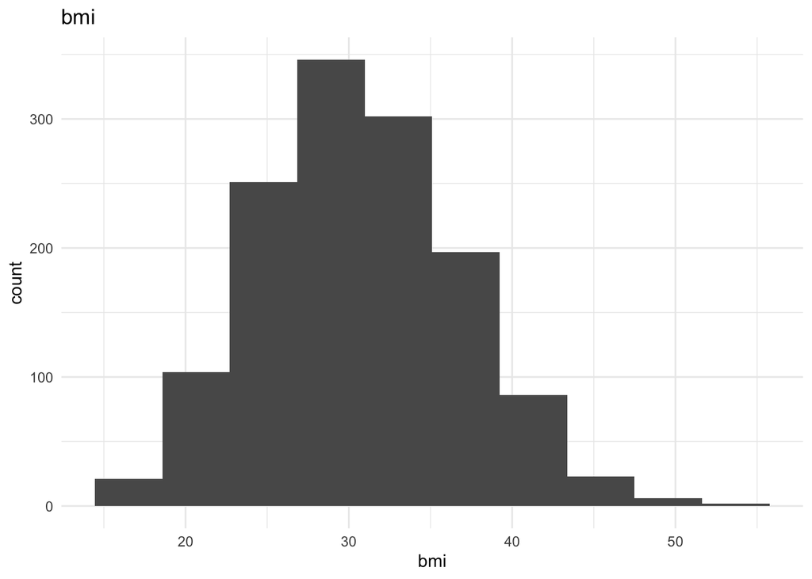

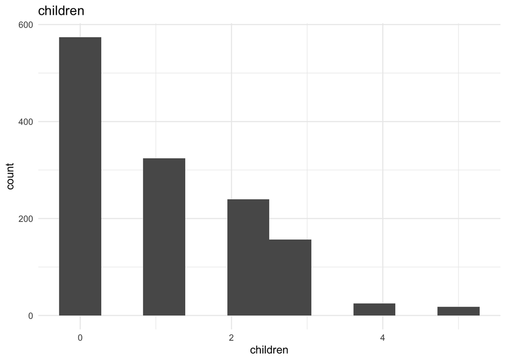

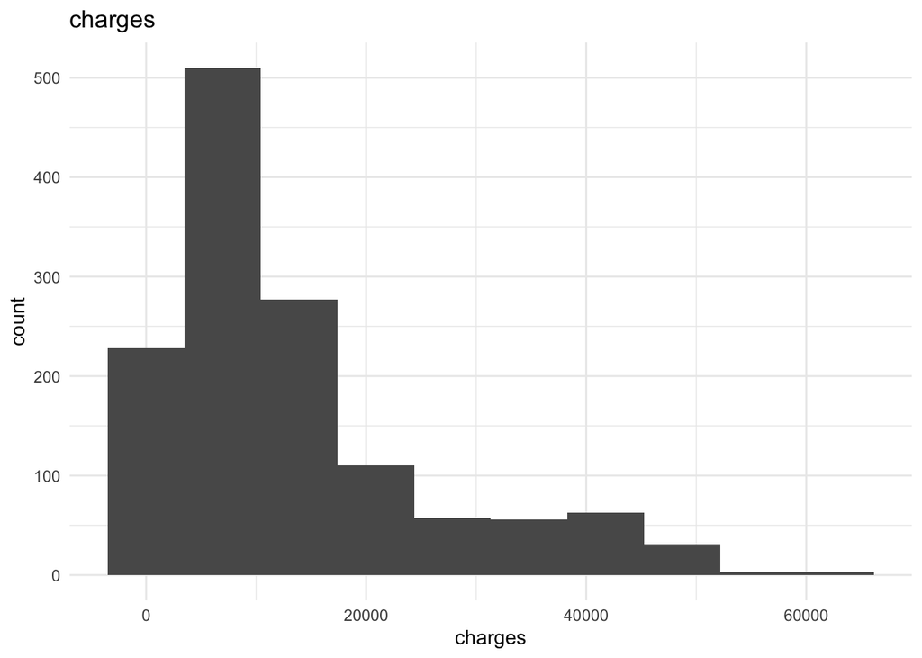

```r
data_numeric <- raw_data[, sapply(raw_data, is.numeric)]
names_numeric <-  colnames(data_numeric)


for (name in names_numeric){
                            hist <- ggplot(data = data_numeric, aes(x = .data[[name]])) +
                                   geom_histogram(bins = 10) +
                                   theme_minimal() +
                                   ggtitle(name)

                            print(hist)
                          }
```

### График плотности по колонке charges.

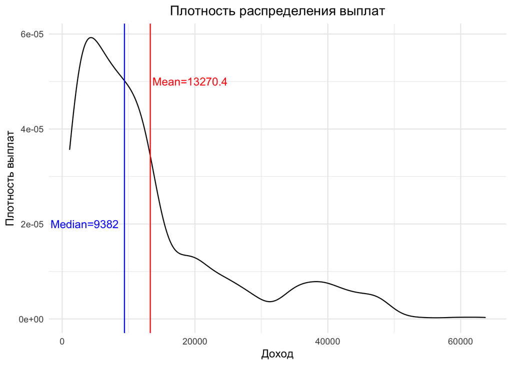

```r
#рассчитаем медиану и среднее для верикальных линий
charges_mean <- round(mean(data_numeric$charges), 1)
charges_median <- round(median(data_numeric$charges), 1)

density_gg <- ggplot(data=data_numeric, aes(x = charges))+
              geom_density()+
              geom_vline(aes(xintercept = charges_mean), color="red")+
               annotate("text",
               x= charges_mean + 6000,
               y=5 * 10^-5,
               label=paste0("Mean=", charges_mean),
               color = "red")+
              geom_vline(aes(xintercept = charges_median), color="blue")+
              annotate("text",
               x= charges_median - 6000,
               y=2 * 10^-5,
               label=paste0("Median=", charges_median),
               color = "blue")+
               labs(x = "Доход", y = "Плотность выплат")+
               ggtitle("Плотность распределения выплат")+
               theme_minimal()+
               theme(plot.title = element_text(hjust = 0.5))

print(density_gg)
```

Сделайте три box_plot по отношению переменных charges и (1) sex (2) smoker (3) region. Подберите тему для графика. Назовите оси.

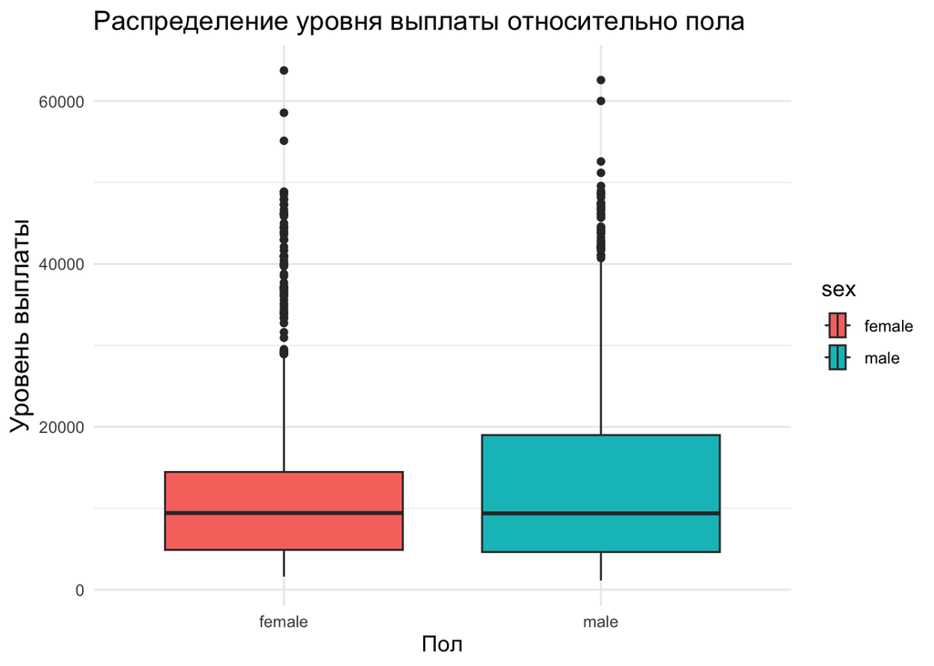

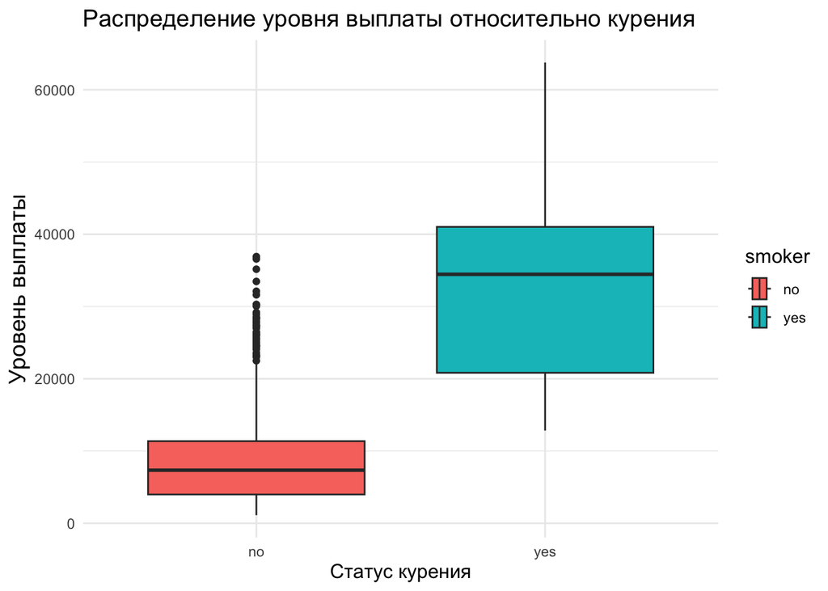

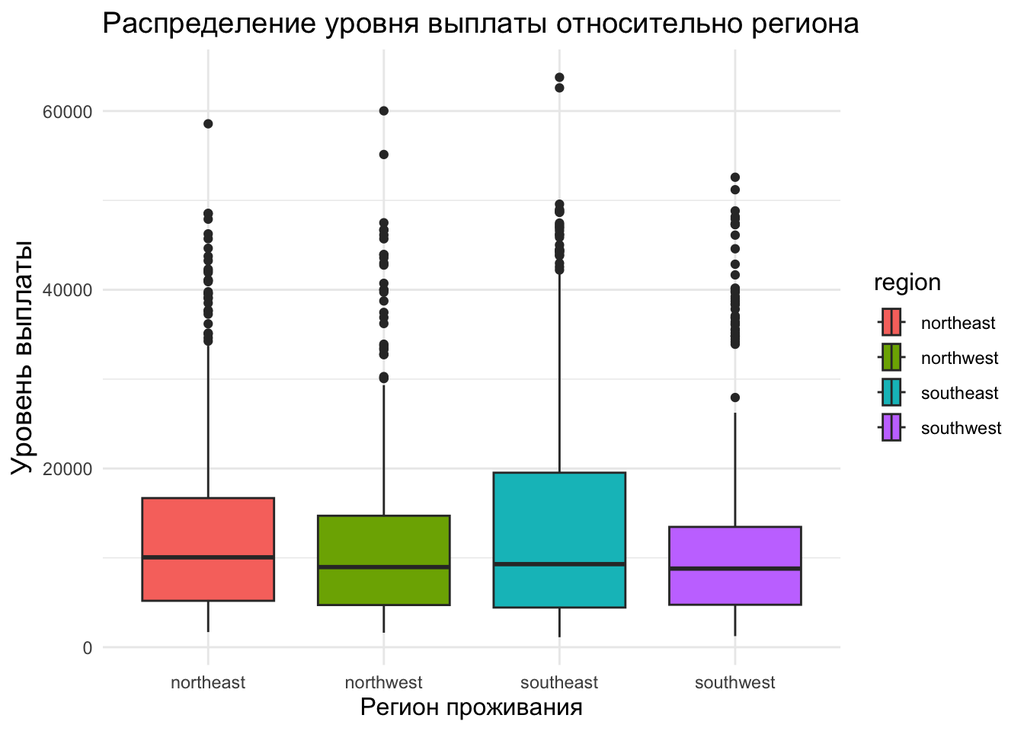

```r
list_of_vars <- c("sex", "smoker", "region")
plot_list <- list()

for (var in list_of_vars) {

  title <- switch (var,
    sex = "Распределение уровня выплаты относительно пола",
    smoker = "Распределение уровня выплаты относительно курения",
    region = "Распределение уровня выплаты относительно региона"
    )

  y_label <- switch (var,
    sex = "Пол",
    smoker = "Статус курения",
    region = "Регион проживания"
    )

charges_box <- ggplot() +
          geom_boxplot(data = raw_data,
                       aes(x = charges, y = .data[[var]], fill = .data[[var]])) +
          theme_minimal() +
          ggtitle(title) +
          labs(y = y_label, x = 'Уровень выплаты') +
          theme( # Ниже идут настройки тем (их огромное количество, но мы меняем лишь две)
            title = element_text(size = 12), # Задаем стандартный размер текста для любого элемента графика
            axis.title.y = element_text(size=14) # Задаём размер для названия оси y отдельно +
            ) +
          coord_flip() # Переворачиваем оси

plot_list[[var]] <- charges_box

}

print(plot_list)
```

Объедините графики из заданий 3 и 4 в один так, чтобы сверху шёл один график из задания 3, а под ним 3 графика из задания 4. Сделайте общее название для графика.

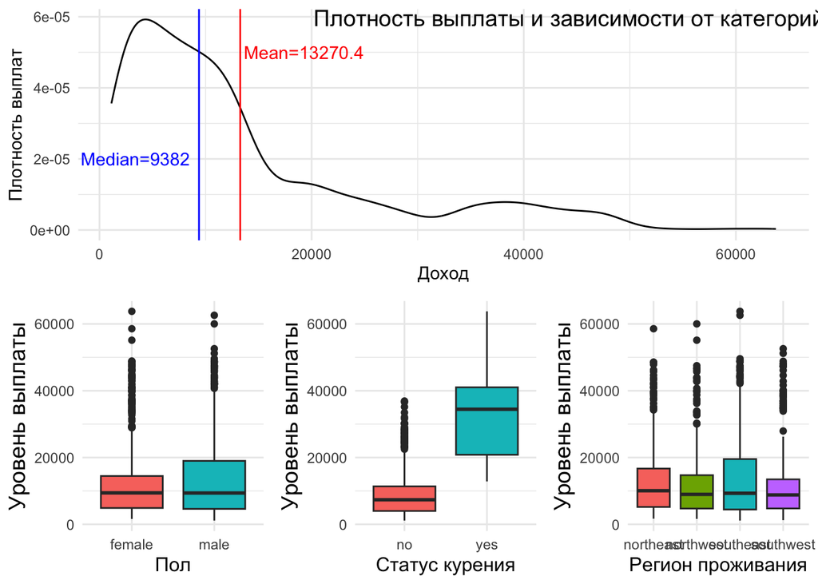

```r
plot_list_combined <- list(
  sex = plot_list[["sex"]],
  smoker = plot_list[["smoker"]],
  region = plot_list[["region"]]
)

common_title <- "Плотность выплаты и зависимости от категорий."


plot_list[["sex"]] <- plot_list[["sex"]] +
  ggtitle(NULL) +
  guides(fill = FALSE)
plot_list[["smoker"]] <- plot_list[["smoker"]] +
  ggtitle(NULL) +
  guides(fill = FALSE)

plot_list[["region"]] <- plot_list[["region"]] +
  ggtitle(NULL) +
  guides(fill = FALSE)

density_gg <- density_gg+
  ggtitle(NULL) +
  guides(fill = FALSE)


combined_plot_densite <- ggarrange(
  density_gg,
  ncol = 1  # Установите количество столбцов на 1 для 'density_gg'
)

# Используйте еще один вызов ggarrange для размещения остальных графиков
combined_plot_box <- ggarrange(
  plot_list[["sex"]],
  plot_list[["smoker"]],
  plot_list[["region"]],
  ncol = 3  # Установите количество столбцов на 3 для остальных графиков
)

combined_plot_all<- ggarrange(
  combined_plot_densite,
  combined_plot_box,
  ncol = 1,
  nrow = 2
)

combined_plot_all <- ggdraw() +
  draw_plot(combined_plot_all, width = 1, height = 1) +
  draw_label(common_title, size = 14, x = 0.7, y = 0.97)

print(combined_plot_all)
```

### Сделайте фасет графика из задания 3 по колонке region.

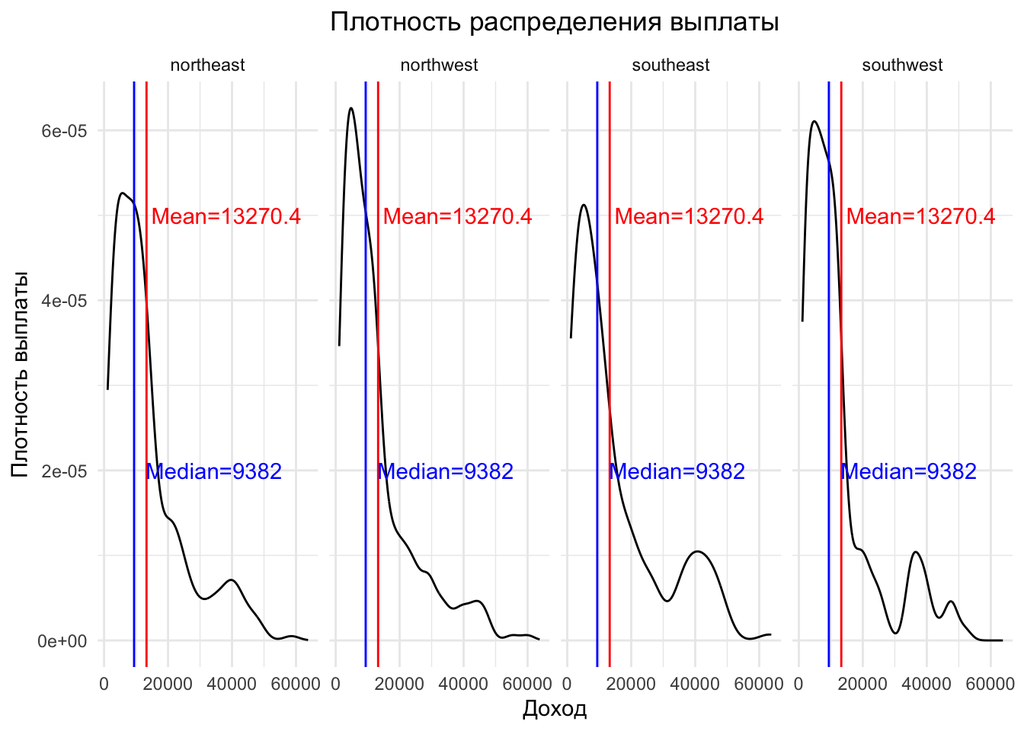

```r
density_gg <- ggplot(data=raw_data, aes(x = charges))+
              geom_density()+
              geom_vline(aes(xintercept = charges_mean), color="red")+
               annotate("text",
               x= charges_mean + 25000, # Изменим привязку для отображения подписей вертикальных осей
               y=5 * 10^-5,
               label=paste0("Mean=", charges_mean),
               color = "red")+
              geom_vline(aes(xintercept = charges_median), color="blue")+
              annotate("text",
               x= charges_median + 25000,
               y=2 * 10^-5,
               label=paste0("Median=", charges_median),
               color = "blue")+
               labs(x = "Доход", y = "Плотность выплаты")+
               ggtitle("Плотность распределения выплаты")+
               facet_grid(. ~ region) + # Добавим разбиение по региону
               theme_minimal()+
               theme(plot.title = element_text(hjust = 0.5))

print(density_gg)
```

Постройте scatter plot отношения переменных age и charges. Добавьте названия осей, название графика и тему. Сделайте так, чтобы числа по оси Х отображались 14 шрифтом.

### scatter plot отношения переменных age и charges + линия тренда

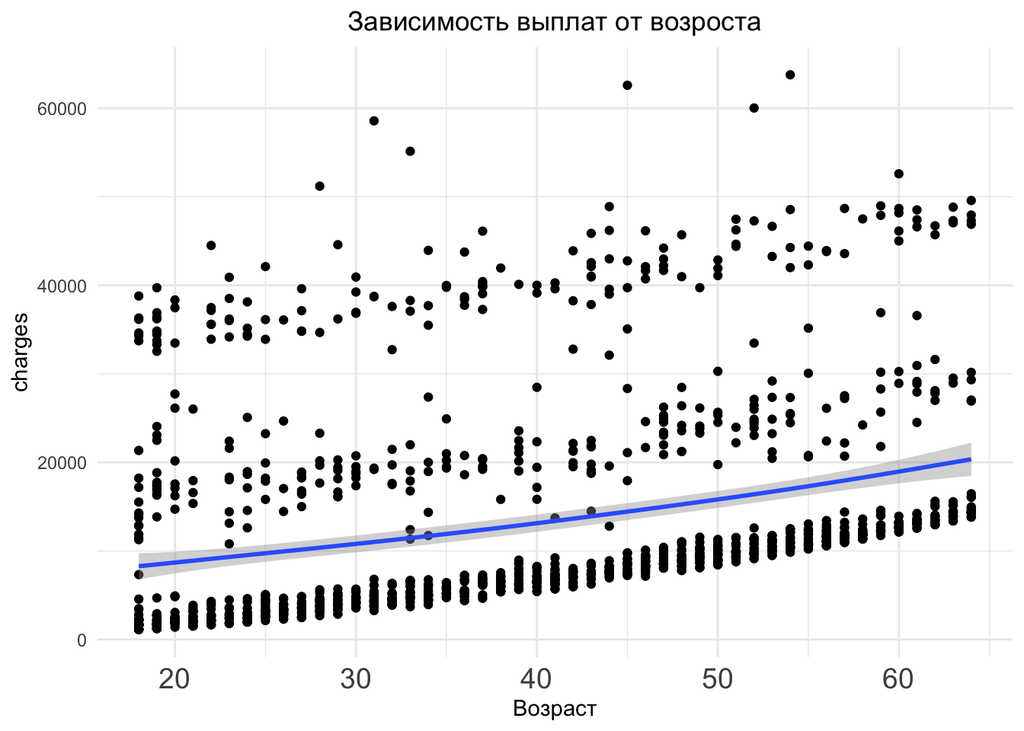

```r
raw_data %>%
  ggplot(aes(x = age, y = charges))+
  geom_point()+
  geom_smooth()+ # добавим линию тренда
  ggtitle("Зависимость выплат от возроста")+
  labs(x = "Возраст", "Величина выплат")+
  theme_minimal()+
  theme(plot.title = element_text(hjust = 0.5),
        axis.text.x = element_text(size = 14))
```

### Разбивка по статусу курения

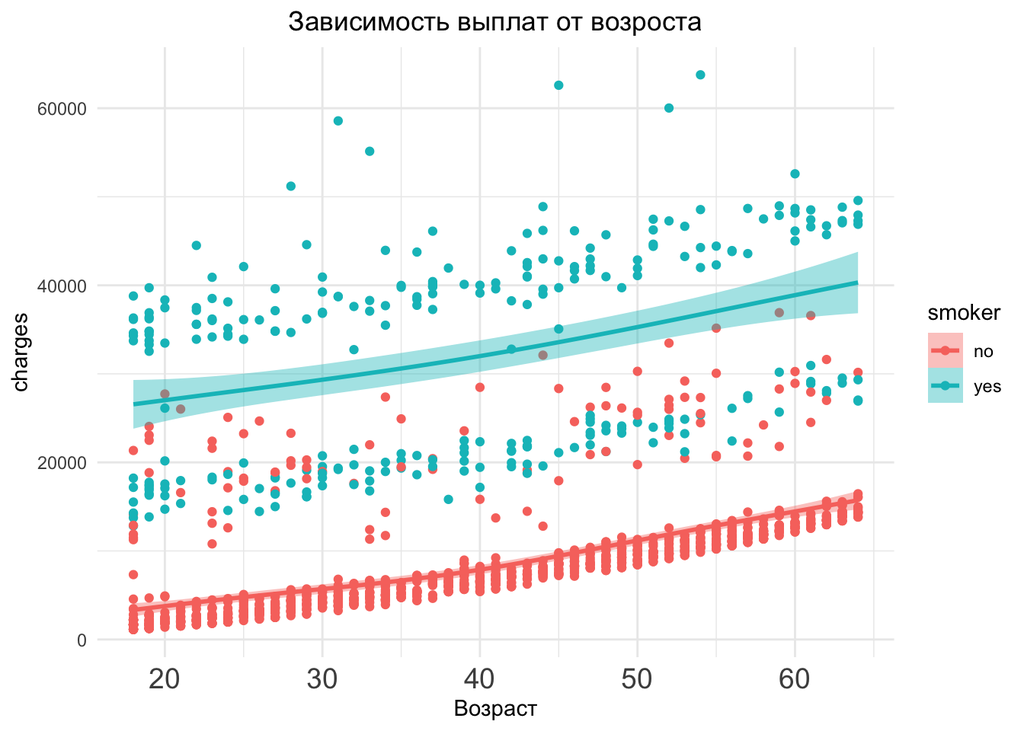

```r
raw_data %>%
  ggplot(aes(x = age, y = charges, color = smoker, fill = smoker, group = smoker))+
  geom_point()+
  geom_smooth()+ # добавим линию тренда
  ggtitle("Зависимость выплат от возроста")+
  labs(x = "Возраст", "Величина выплат")+
  theme_minimal()+
  theme(plot.title = element_text(hjust = 0.5),
        axis.text.x = element_text(size = 14))
```

### Повторим анализ для BMI

### scatter plot отношения переменных bmi и charges + линия тренда

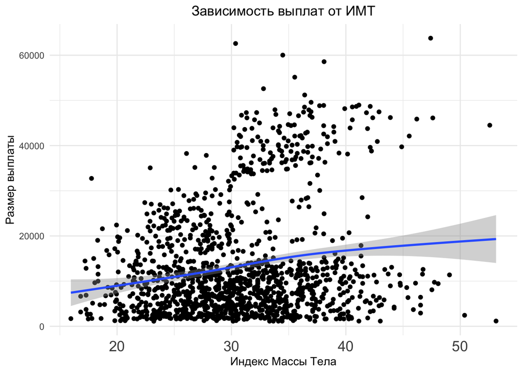

```r
raw_data %>%
  ggplot(aes(x = bmi, y = charges))+
  geom_point()+
  geom_smooth()+ # добавим линию тренда
  ggtitle("Зависимость выплат от ИМТ")+
  labs(y = "Размер выплаты", x = "Индекс Массы Тела")+
  theme_minimal()+
  theme(plot.title = element_text(hjust = 0.5),
        axis.text.x = element_text(size = 14))
```

### Разбивка по статусу курения

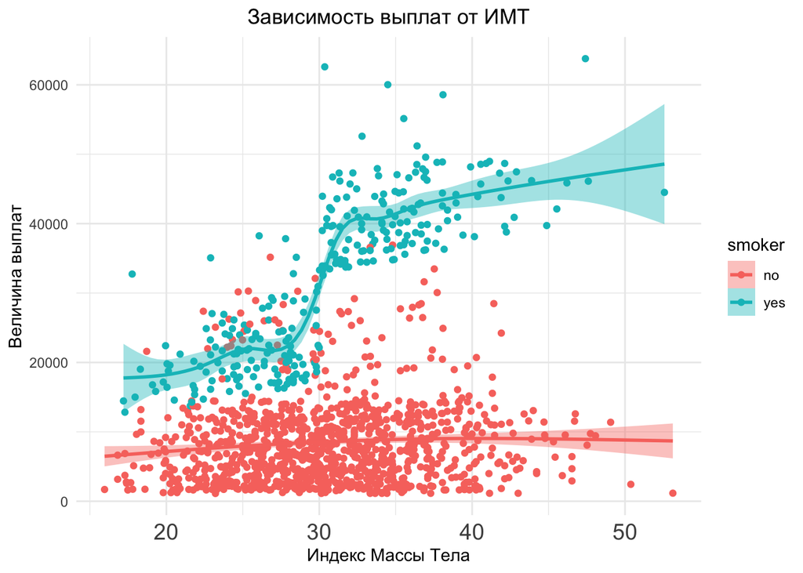

```r
raw_data %>%
  ggplot(aes(x = bmi, y = charges, color = smoker, fill = smoker, group = smoker))+
  geom_point()+
  geom_smooth()+ # добавим линию тренда
  ggtitle("Зависимость выплат от ИМТ")+
  labs(x = "Индекс Массы Тела", y = "Величина выплат")+
  theme_minimal()+
  theme(plot.title = element_text(hjust = 0.5),
        axis.text.x = element_text(size = 14))
```

### 11 - 13 Врпросы к данным

11. каков процент мужчин и женщин у пациентов с выплатой более 40 тысяч?

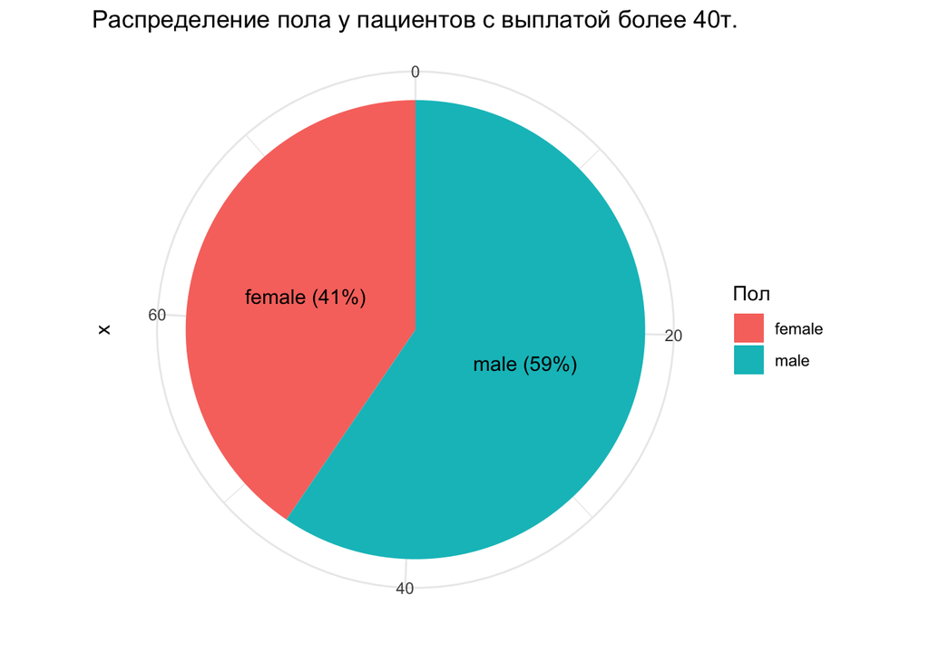

```r
library(ggplot2)


# Фильтруем данные и создаем таблицу
pie_char_40 <- raw_data %>% filter(charges >= 40000)
data_pie <- data.frame(table(pie_char_40$sex))

# Создаем круговую диаграмму
p <- ggplot(data_pie, aes(x = "", y = Freq, fill = Var1)) +
  geom_bar(stat = "identity") +
  coord_polar(theta = "y") +
  theme_minimal() +
  labs(y = "", title = "Распределение пола у пациентов с выплатой более 40т.")+
  theme(plot.title = element_text(hjust = 0.5))

# Добавляем метки с процентами
p + geom_text(aes(label = paste0(Var1, " (", scales::percent(Freq / sum(Freq)), ")"), y = Freq), position = position_stack(vjust = 0.5))+
  labs(fill = "Пол")
```

Аргументация выбора типа графика: так как есть две выраженные доли, такие как пол, я предположил что корректно их отобразить используя круговую диаграмму с указание процентов на случай если доли будут практически равными, что затруднит определение какая доля больше.

12. Сравнение распределений: сравнить распределение значений затрат на медицинское обслуживание для двух групп: курящих и некурящих. Это может помочь определить, есть ли статистически значимые различия в затратах между этими двумя группами.

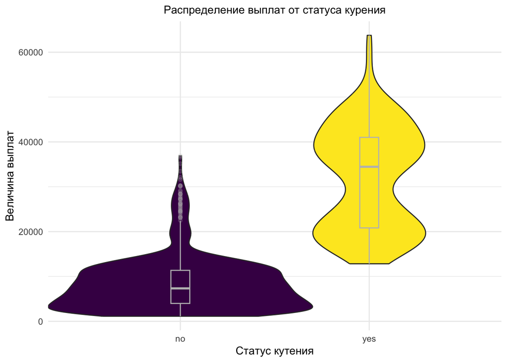

```r
# sample size
sample_size = raw_data %>% group_by(smoker) %>% summarize(num=n())

# Plot
# sample size
sample_size = raw_data %>% group_by(smoker) %>% summarize(num = n())

# Plot
raw_data %>%
  left_join(sample_size) %>%
  mutate(myaxis = paste0(smoker, "\n", "n=", num)) %>%
  ggplot(aes(x = smoker, y = charges, fill = smoker)) +
  geom_violin(width = 1.4) +
  geom_boxplot(width = 0.1, color = "grey", alpha = 0.2) +
  scale_fill_viridis(discrete = TRUE) +
  theme(
    legend.position = "none",
    plot.title = element_text(size = 11)
  ) +
  theme(plot.title = element_text(hjust = 0.5)) +
  ggtitle("Распределение выплат от статуса курения") +
  xlab("Статус кутения") +
  ylab("Величина выплат")
```

я решил “обогатить” боксплот добаввив виолин-плот.

Скрипичная диаграмма предоставляет более полное представление о распределении данных по сравнению с простой гистограммой или боксплотом. Она позволяет видеть как основные статистики (медиана, квартили), так и форму и плотность распределения. Это полезно для сравнения нескольких групп данных или для исследования данных в контексте категориальных переменных.

13. Каково распределение затрат на медицинское обслуживание (столбец “charges”) для некурящих женщин (столбец “smoker” равен “no” и “sex” равен “female”) в наших данных?

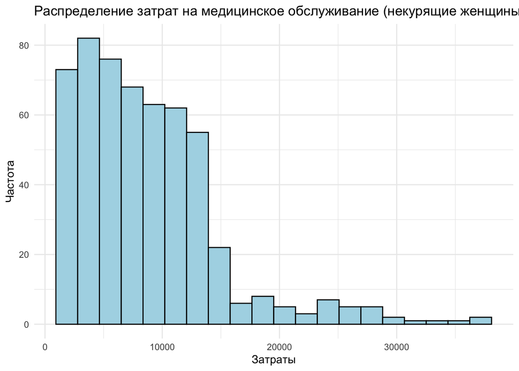

```r
# Создание подвыборки данных для некурящих женщин
sub_data <- raw_data %>% filter(smoker == "no" & sex == "female")

# Построение гистограммы
ggplot(sub_data, aes(x = charges)) +
  geom_histogram(fill = "lightblue", color = "black", bins = 20) +
  labs(
    title = "Распределение затрат на медицинское обслуживание (некурящие женщины)",
    x = "Затраты",
    y = "Частота"
  ) +
  theme_minimal()
```

Гистограмма была выбрана для визуализации, потому что она позволяет легко увидеть, как распределены затраты на медицинское обслуживание и определить характер распределения (например, нормальное, скошенное, мультимодальное и т. д.).